# Unit 3 Project

Sahar Revah

2026-02-06

```r
library(tidyverse)
library(ggplot2)
library(GGally)
library(MASS)
library(klaR)
library(dismo)
```

Below is a template to get you started on the Unit 3 Project. Make sure you edit the metadata above to include your name. For questions that include code, the template to produce `R` chunks is below. **Any code you write that produces an output must be fully visible in the HTML document you hand in!**

## Notes (2/10/26)

Reproductive Isolation:

- prezygotic (before the fusion of the gametes) –> mechanical, **temporal**, **habitat/spatial**, behavioral
- allopatric speciation –> change in habitat where there is a geographical barrier that causes a speciation event
- sympatric speciation –> speciation that can occur without a geographical barrier
- autopolyploid and allopolyploid

# Part I: Morphological Data

## Notes

linear discriminate analysis –> we use this when we want to combine multiple data points to say something about the data

## Question 1

```r
mean_table <- iris %>%
  group_by(Species) %>%
  summarise(
    avg_sepal_len = mean(Sepal.Length),
    avg_sepal_wid = mean(Sepal.Width),
    avg_petal_len = mean(Petal.Length),
    avg_petal_wid = mean(Petal.Width)

  )
print(mean_table)
```

```
## # A tibble: 3 × 5
##   Species    avg_sepal_len avg_sepal_wid avg_petal_len avg_petal_wid
##   <fct>              <dbl>         <dbl>         <dbl>         <dbl>
## 1 setosa              5.01          3.43          1.46         0.246
## 2 versicolor          5.94          2.77          4.26         1.33
## 3 virginica           6.59          2.97          5.55         2.03
```

## Question 2

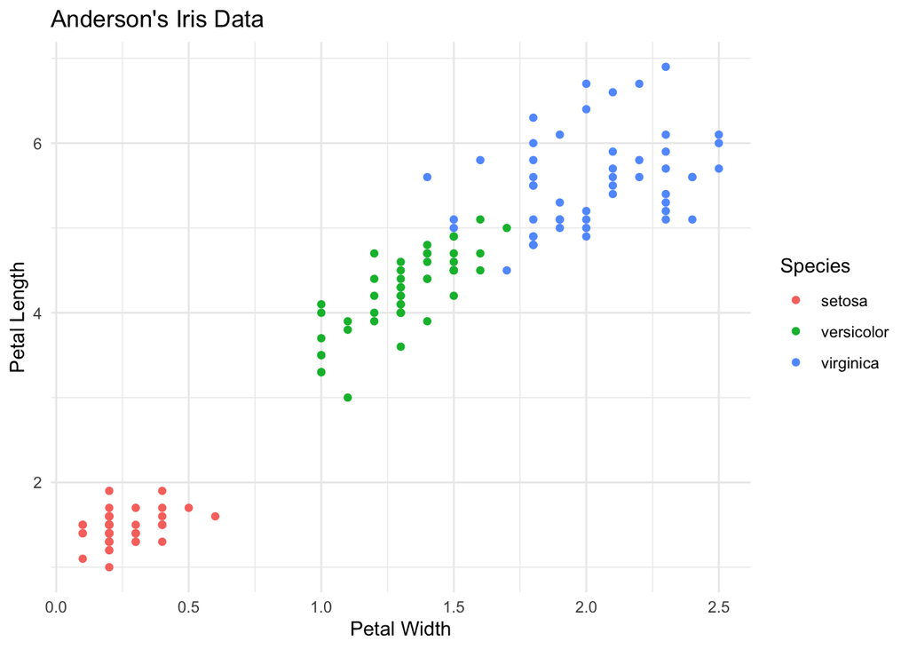

```r
ggplot(iris, aes(x = Petal.Width, y = Petal.Length, color = Species)) + geom_point() + labs(title = "Anderson's Iris Data", x = "Petal Width", y = "Petal Length") + theme_minimal()
```

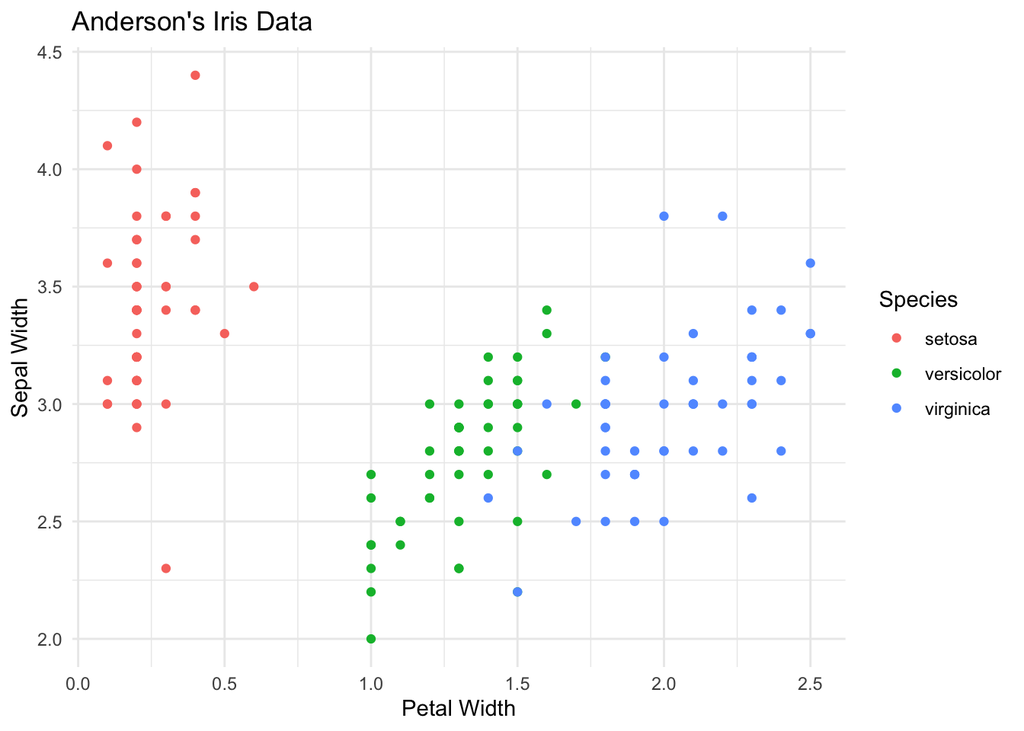

```r
ggplot(iris, aes(x = Petal.Width, y = Sepal.Width, color = Species)) + geom_point() + labs(title = "Anderson's Iris Data", x = "Petal Width", y = "Sepal Width") + theme_minimal()
```

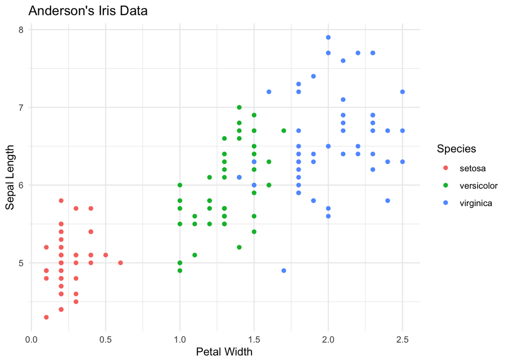

```r
ggplot(iris, aes(x = Petal.Width, y = Sepal.Length, color = Species)) + geom_point() + labs(title = "Anderson's Iris Data", x = "Petal Width", y = "Sepal Length") + theme_minimal()
```

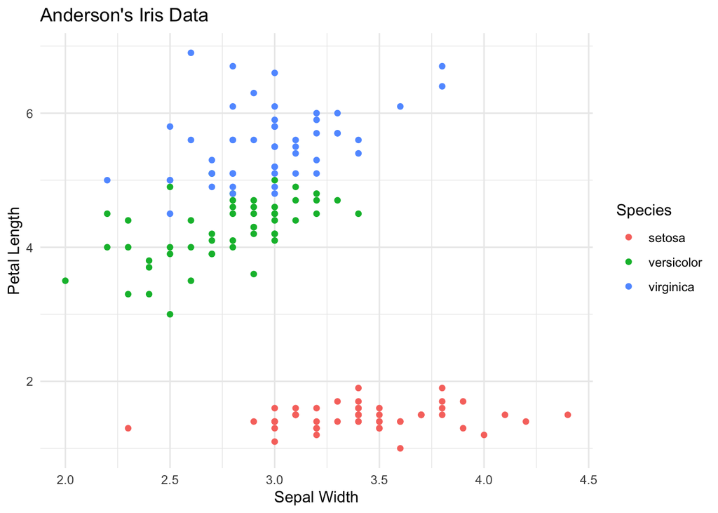

```r
ggplot(iris, aes(x = Sepal.Width, y = Petal.Length, color = Species)) + geom_point() + labs(title = "Anderson's Iris Data", x = "Sepal Width", y = "Petal Length") + theme_minimal()
```

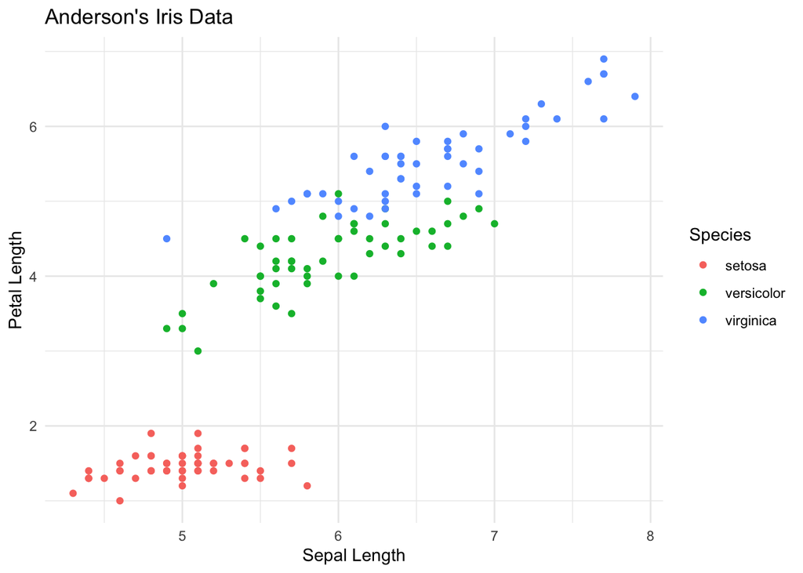

```r
ggplot(iris, aes(x = Sepal.Length, y = Petal.Length, color = Species)) + geom_point() + labs(title = "Anderson's Iris Data", x = "Sepal Length", y = "Petal Length") + theme_minimal()
```

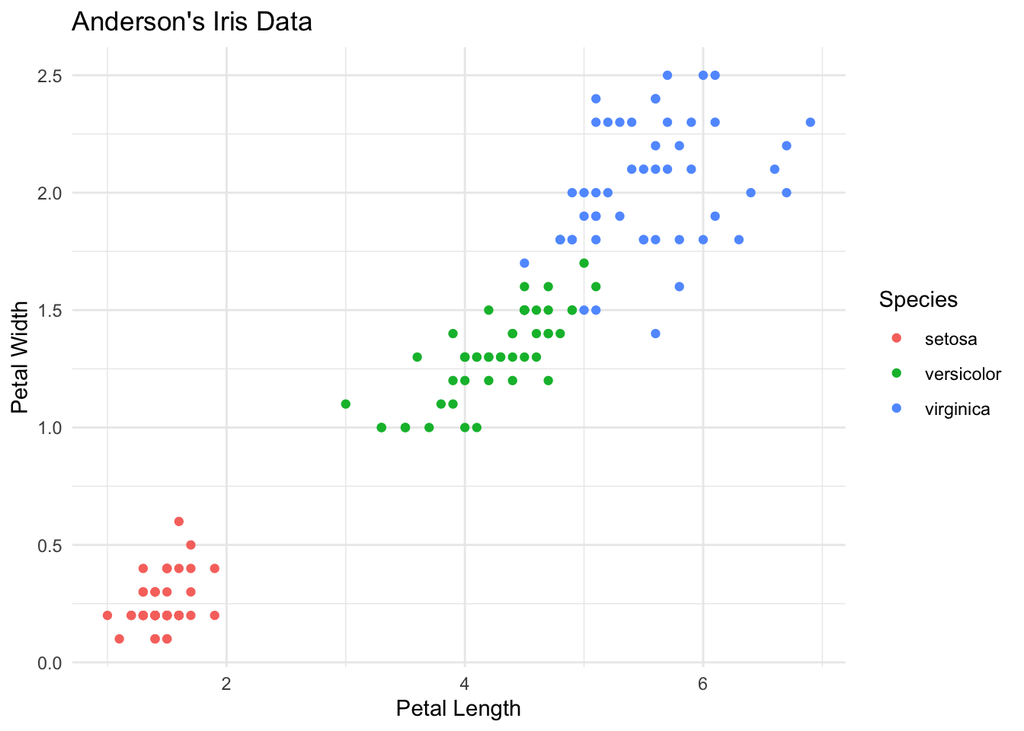

```r
ggplot(iris, aes(x = Petal.Length, y = Petal.Width, color = Species)) + geom_point() + labs(title = "Anderson's Iris Data", x = "Petal Length", y = "Petal Width") + theme_minimal()
```

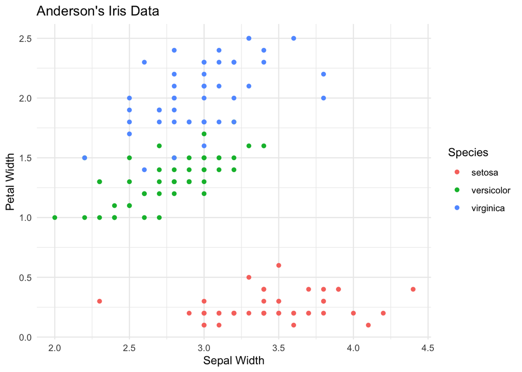

```r
ggplot(iris, aes(x = Sepal.Width, y = Petal.Width, color = Species)) + geom_point() + labs(title = "Anderson's Iris Data", x = "Sepal Width", y = "Petal Width") + theme_minimal()
```

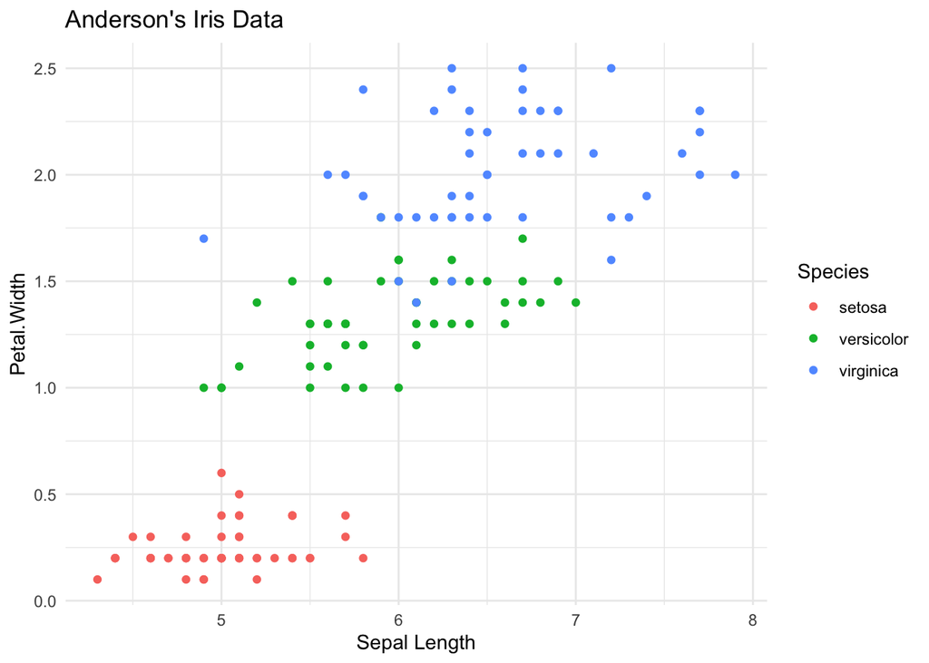

```r
ggplot(iris, aes(x = Sepal.Length, y = Petal.Width, color = Species)) + geom_point() + labs(title = "Anderson's Iris Data", x = "Sepal Length", y = "Petal.Width") + theme_minimal()
```

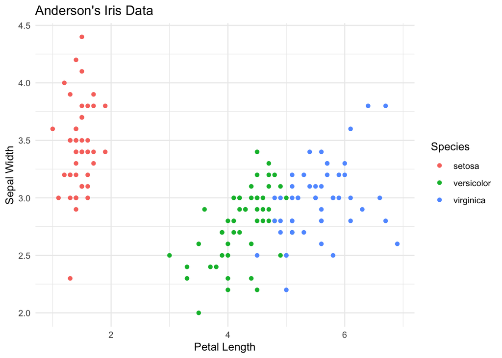

```r
ggplot(iris, aes(x = Petal.Length, y = Sepal.Width, color = Species)) + geom_point() + labs(title = "Anderson's Iris Data", x = "Petal Length", y = "Sepal Width") + theme_minimal()
```

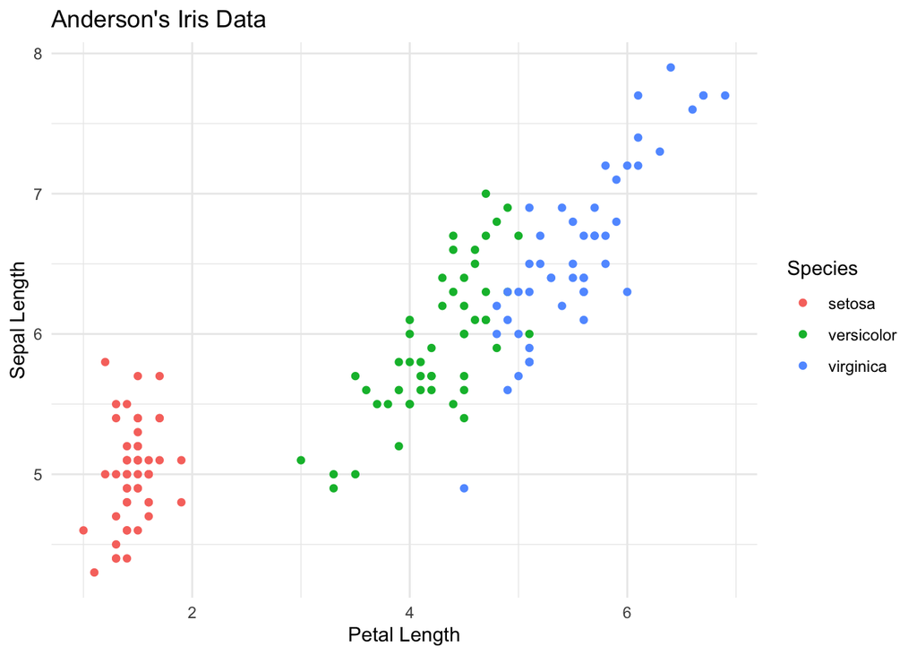

```r
ggplot(iris, aes(x = Petal.Length, y = Sepal.Length, color = Species)) + geom_point() + labs(title = "Anderson's Iris Data", x = "Petal Length", y = "Sepal Length") + theme_minimal()
```

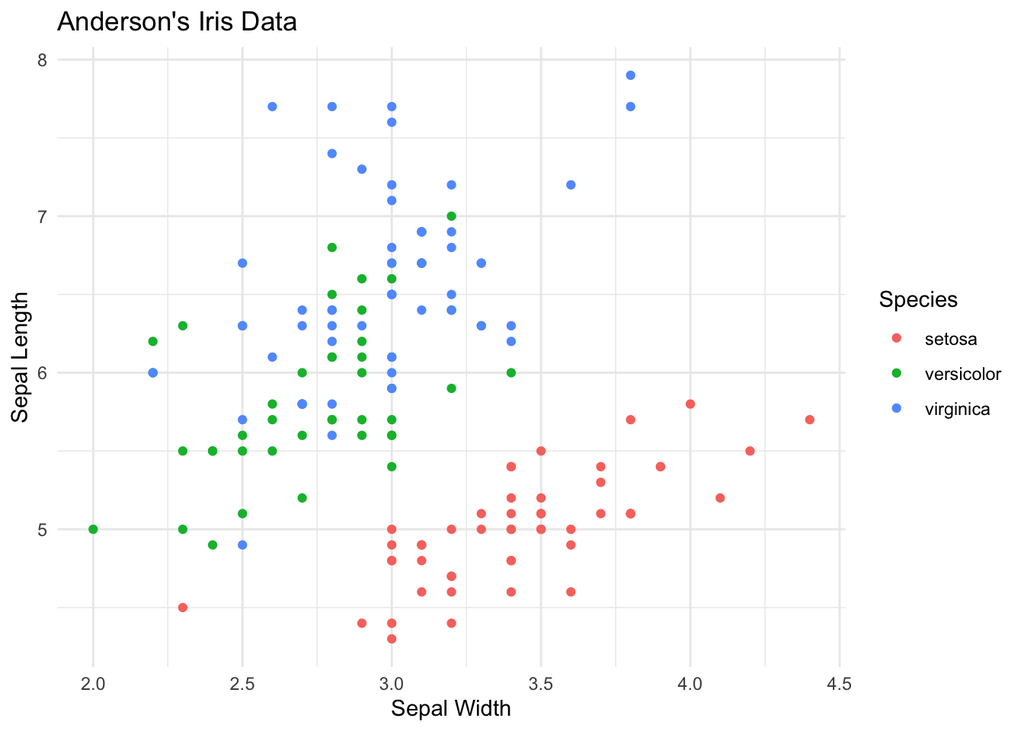

```r
ggplot(iris, aes(x = Sepal.Width, y = Sepal.Length, color = Species)) +
geom_point() + labs(title = "Anderson's Iris Data", x = "Sepal Width", y = "Sepal Length") + theme_minimal()
```

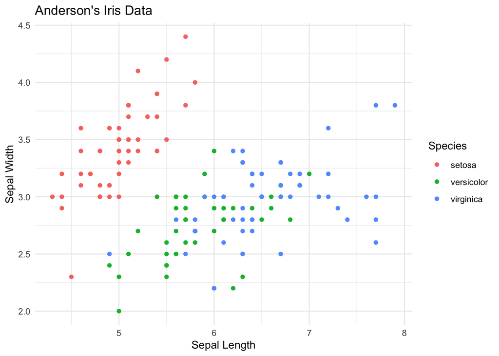

```r
ggplot(iris, aes(x = Sepal.Length, y = Sepal.Width, color = Species)) + geom_point() + labs(title = "Anderson's Iris Data", x = "Sepal Length", y = "Sepal Width")+ theme_minimal()
```

## Question 3

```r
SepalLandPetalL <- iris %>%
    dplyr::select(Sepal.Length:Petal.Length)

Species_iris <- iris %>%
    pull(Species)

fitSLPL <- lda(SepalLandPetalL, Species_iris)
pred.fitSLPL <- predict(fitSLPL)
predictionSLPL <- pred.fitSLPL$class

prediction.tableSLPL <- table(iris$Species, predictionSLPL)
prediction.tableSLPL
```

```
##             predictionSLPL
##              setosa versicolor virginica
##   setosa         50          0         0
##   versicolor      0         48         2
##   virginica       0          3        47
```

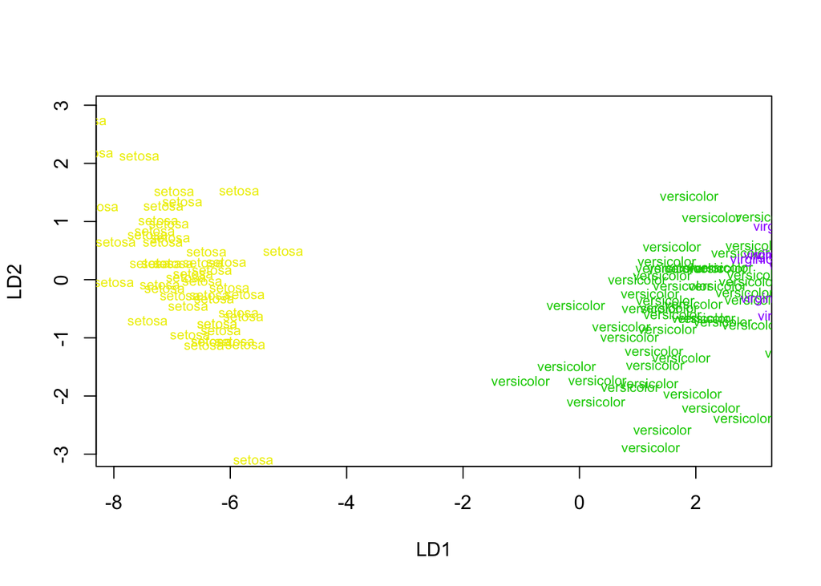

```r
new.irisSLPL <- iris %>%
    dplyr::select(Species) %>%
    add_column(predictionSLPL)
plot(fitSLPL, col = c("yellow2", "green3", "purple1")[unclass(new.irisSLPL$Species)], xlim = c(-5, 0))
```

```r
#-----
PetalLandW <- iris %>%
  dplyr::select(Petal.Length:Petal.Width)

fitPLW <- lda(PetalLandW, Species_iris)
pred.fitPLW <- predict(fitPLW)
predictionPLW <- pred.fitPLW$class

prediction.tablePLW <- table(iris$Species, predictionPLW)
prediction.tablePLW
```

```
##             predictionPLW
##              setosa versicolor virginica
##   setosa         50          0         0
##   versicolor      0         48         2
##   virginica       0          4        46
```

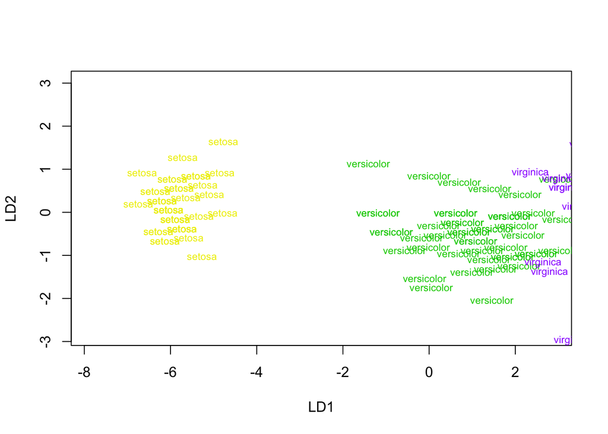

```r
new.irisPLW <- iris %>%
    dplyr::select(Species) %>%
    add_column(predictionPLW)
plot(fitPLW, col = c("yellow2", "green3", "purple1")[unclass(new.irisPLW$Species)], xlim = c(-5, 0))
```

In the previous question it looked like the two graphs with sepal length and petal length, as well as petal length and petal width seemed to be the best separated for species out of all the other graphs. When making a prediction table, it seemed that these measurements are not perfect predictors, but can estimate the species fairly well. It seems that the comparison between sepal length and petal length is slightly more accurate.

## Question 4

I used the LDA analysis to determine which measurement out of the two I chose predicts most accurately the species based on the data. Based on this data, I believe Edgar Anderson’s predictions were fairly accurate, but it is possible that he was mistaken in some classification of certain individuals, similar to the prediction model due to their similarily. Though, there are many other factors in speciation that do not necessarily depend on sepals and petals, and perhaps there are other identifiers for different species that he considered.

# Part II: Geographical and temporal data

```r
library(dismo)

get.gbif <- function(genus, species, na.rm = TRUE, crop = TRUE) {
    # GBIF query
    gps <- gbif(genus, species, geo = FALSE)
    # drop NA entries; note that this option is visited only with na.rm=TRUE
    if (na.rm) {
        gps <- subset(gps, !is.na(lon) & !is.na(lat))
    }
    if (crop) {
        keep <- c(which(colnames(gps) == "species"), which(colnames(gps) == "lat"), which(colnames(gps) == "lon"), which(colnames(gps) ==
            "month"))
        gps <- gps[keep]
    }
    return(gps)
}
library(maps)
```

## Question 1

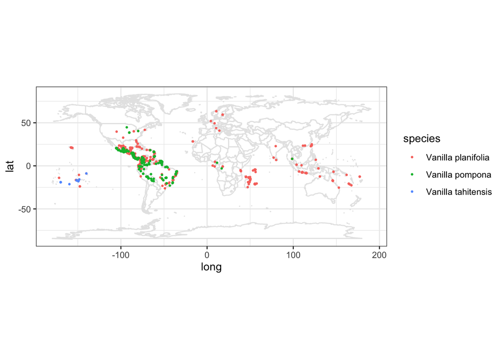

```r
vanilla_planifolia <- get.gbif("Vanilla", "planifolia")
vanilla_pompona <- get.gbif("Vanilla", "pompona")
vanilla_tahitensis <- get.gbif("Vanilla","tahitensis")

vanilla_orchid_gps <- bind_rows(vanilla_planifolia,vanilla_pompona,vanilla_tahitensis)
write_csv(vanilla_orchid_gps, file = "vanilla_orchid_gps.csv", col_names = TRUE)
vanilla_orchid_gps <- read_csv("vanilla_orchid_gps.csv")

library(maps)

ggplot2::theme_set(theme_bw())
world.map <- map_data(map="world")
mexico.map <- subset(world.map, region == "Mexico")

ggplot(world.map, aes(long,lat, group=group)) + geom_polygon(fill = "white", color = "gray90") + coord_quickmap() +geom_point(data= vanilla_orchid_gps, mapping = aes(x = lon, y = lat, group = species, color = species), size = 0.5)
```

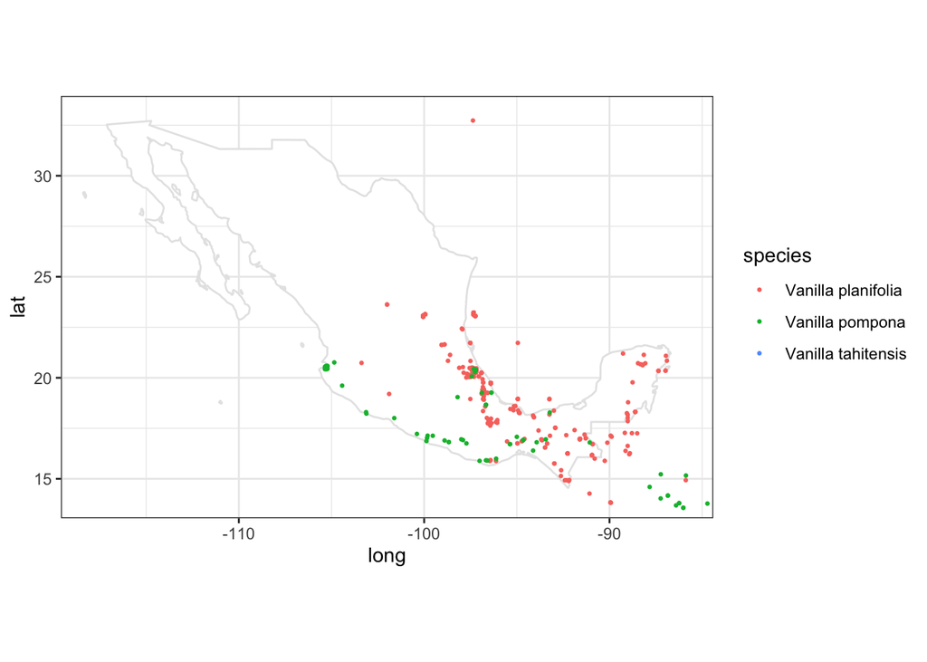

```r
ggplot(mexico.map, aes(long,lat, group=group)) + geom_polygon(fill = "white", color = "gray90") + coord_quickmap(xlim = c(-118,-86), ylim = c(14,33)) + geom_point(data= vanilla_orchid_gps, mapping = aes(x = lon, y = lat, group = species, color = species), size = 0.5)
```

I chose to display three vanilla orchid species. It seems like two species occur around the same areas, with Vanilla planifolia being more common worldwide. Vanilla tahitensis is popular at a very specific region of the world only.

## Question 2

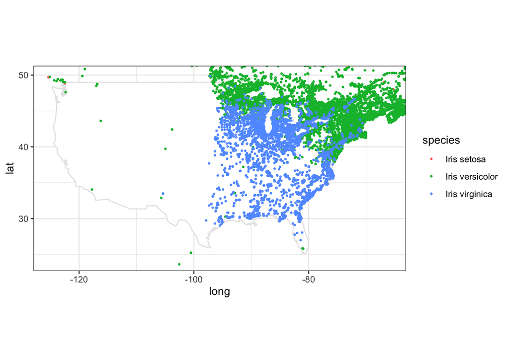

```r
iris_gps <- read_csv("iris_gps.csv")

usa.map <- map_data(map = "usa")

ggplot(usa.map, aes(long,lat, group=group)) + geom_polygon(fill = "white", color = "gray90") + coord_quickmap(xlim = c(-66, -125), ylim = c(24, 50)) + geom_point(data= iris_gps, mapping = aes(x = lon, y = lat, group = species, color = species), size = 0.5)
```

## Question 3

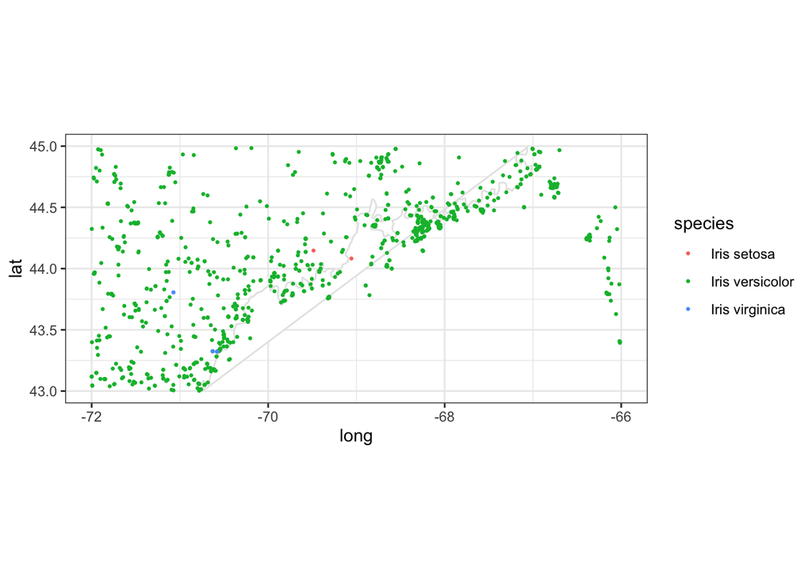

```r
iris_gps_northeast_only <- iris_gps %>% filter(
  lon >= -72 & lon <= -66 & lat >= 43 & lat <= 45)

us_northeast_map <- usa.map %>%
  filter( long >= -72 & long <= -66 & lat >= 43 & lat <= 45)

ggplot(us_northeast_map, aes(long,lat, group=group)) + geom_polygon(fill = "white", color = "gray90") + coord_quickmap(xlim = c(-66, -72), ylim = c(43, 45)) + geom_point(data= iris_gps_northeast_only, mapping = aes(x = lon, y = lat, group = species, color = species), size = 0.5)
```

## Question 4

It looks like Iris versicolor is widely in the northeast, while Iris virginica is focused in the central and southeast. Iris setosa is rarely seen in the US. It is possible that the species got separated by geographies, causing their individual speciation.